# Categorical Evaluation Report

CDC FluSight Team

October 29, 2026

For the 2026-2027 influenza season, CDC called for national and jurisdiction categorical probability predictions for the direction and magnitude of changes in hospitalization rates per 100k population. The collection period began October 7, 2026 and will run through May 26, 2027.

This report is supported by work from colleagues in the Reich Lab at UMass-Amherst, Jessica Davis at Northeastern University, and Gursharn Kaur and Srini Venkatramanan at University of Virginia.

Categorical forecasts are evaluated using the Brier Score, Brier Skill Score, and Ranked Probability Score. All scores are defined below. Models presented include the FluSight-ensemble - an ensemble of submitted categorical forecasts and FluSight-equal_cat which is used as a baseline comparison and is comprised of equal probabilities (0.2) for each category in each jurisdiction each week.

*Higher skill scores are better*

## Observed trends as of October 24, 2026

Trend from week T

### T-1

For one-week ahead rate trends or the change from week T-1 to week T (horizon = 0):

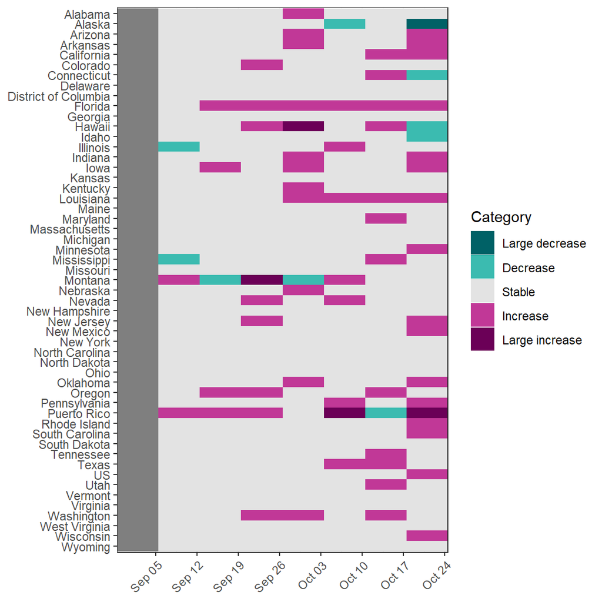

**Stable:** forecasted changes in hospitalizations qualify as stable if either the magnitude of the rate change is less than 0.3/100k OR the corresponding magnitude of the count change is less than 10.  
**Increase:** positive forecasted changes that do not qualify as stable and for which the forecasted rate change is less than 1.7/100k.  
**Large increase:** positive forecasted rate changes that do not qualify as stable and for which the forecasted rate change is larger than or equal to 1.7/100k.  
**Decrease:** negative forecasted rate changes that do not qualify as stable and for which the magnitude of the forecasted rate change is less than 1.7/100k.  
**Large decrease:** negative forecasted rate changes that do not qualify as stable and for which the magnitude of the forecasted rate change is larger than or equal to 1.7/100k.

### T-2

For two-week ahead rate trends or the change from week T-2 to week T (horizon = 1):

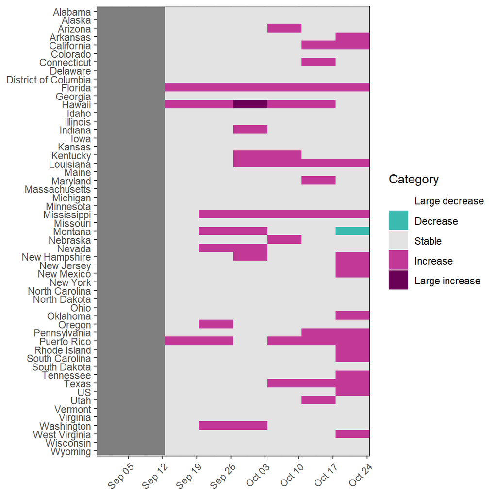

**Stable:** forecasted changes in hospitalizations qualify as stable if either the magnitude of the rate change is less than 0.5/100k OR the corresponding magnitude of the count change is less than 10.  
**Increase:** positive forecasted changes that do not qualify as stable and for which the forecasted rate change is less than 3/100k.  
**Large increase:** positive forecasted rate changes that do not qualify as stable and for which the forecasted rate change is larger than or equal to 3/100k.  
**Decrease:** negative forecasted rate changes that do not qualify as stable and for which the magnitude of the forecasted rate change is less than 3/100k.  
**Large decrease:** negative forecasted rate changes that do not qualify as stable and for which the magnitude of the forecasted rate change is larger than or equal to 3/100k.

### T-3

For three-week ahead rate trends or the change from week T-3 to week T (horizon = 2):

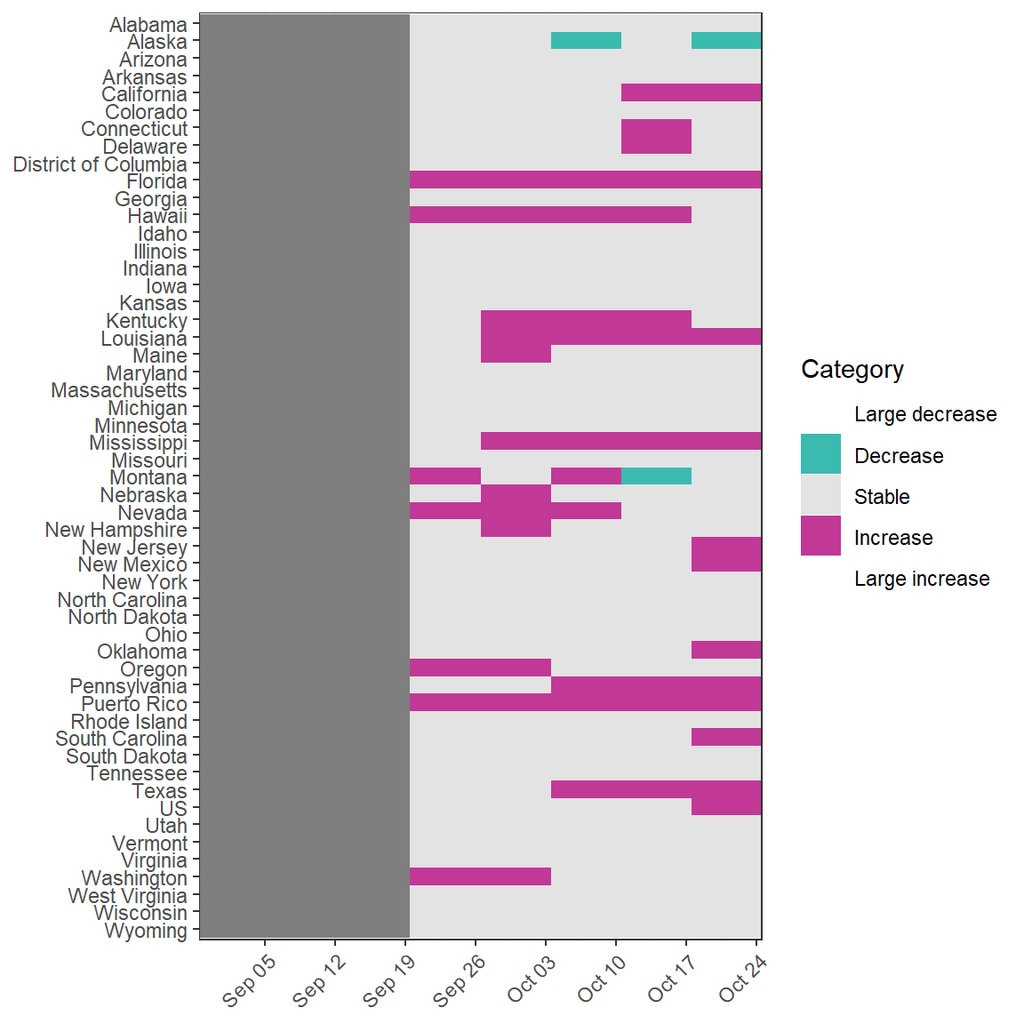

**Stable:** forecasted changes in hospitalizations qualify as stable if either the magnitude of the rate change is less than 0.7/100k OR the corresponding magnitude of the count change is less than 10.  
**Increase:** positive forecasted changes that do not qualify as stable and for which the forecasted rate change is less than 4/100k.  
**Large increase:** positive forecasted rate changes that do not qualify as stable and for which the forecasted rate change is larger than or equal to 4/100k.  
**Decrease:** negative forecasted rate changes that do not qualify as stable and for which the magnitude of the forecasted rate change is less than 4/100k.  
**Large decrease:** negative forecasted rate changes that do not qualify as stable and for which the magnitude of the forecasted rate change is larger than or equal to 4/100k.

### T-4

For four-week ahead rate trends or the change from week T-4 to week T (horizon = 3):

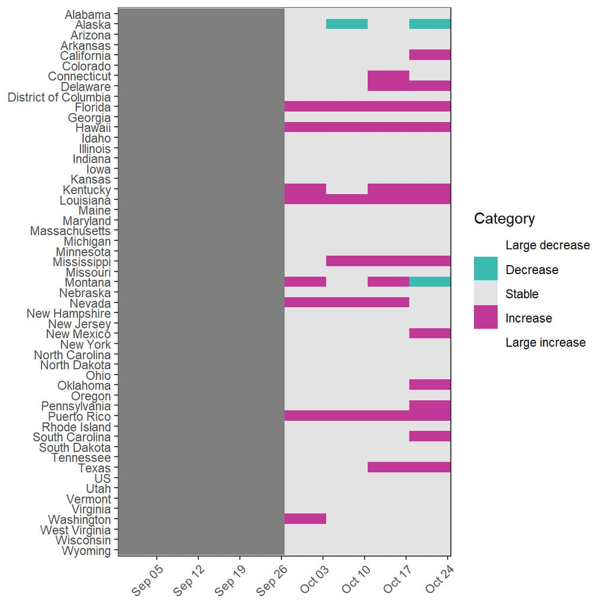

**Stable:** forecasted changes in hospitalizations qualify as stable if either the magnitude of the rate change is less than 1/100k OR the corresponding magnitude of the count change is less than 10.  
**Increase:** positive forecasted changes that do not qualify as stable and for which the forecasted rate change is less than 5/100k.  
**Large increase:** positive forecasted rate changes that do not qualify as stable and for which the forecasted rate change is larger than or equal to 5/100k.  
**Decrease:** negative forecasted rate changes that do not qualify as stable and for which the magnitude of the forecasted rate change is less than 5/100k.  
**Large decrease:** negative forecasted rate changes that do not qualify as stable and for which the magnitude of the forecasted rate change is larger than or equal to 5/100k.

## Brier Score and Ranked Probablity Score

### Definitions

Let $\{-2,-1,0,1,2\}$ be the numeric representation of the categories {“large_decrease”, “decrease”, “stable”, “increase”, “large_increase”}. Then for a model $m$, location $loc$, and horizon $h$

Ranked Probability Scores is given by:
$$RPS(m, loc, h) = \frac{1}{4}\sum_{i=-2}^2 \left( \hat{F}(i)-
F(i)\right)^2$$
where $\hat{F}$ and $F$ denotes the forecast CDF and observed CDF on the discrete state space $\{-2,-1,0,1,2\}$.

Average RPS (for a model $m$ and location $loc$) is given by:
$$RPS(m, loc) = \frac{1}{4} \sum_{h=0}^3 RPS(m,
loc, h)$$

Similarly, average Brier score (for a model $m$ and location $loc$) is given by:
$$BS(m, loc) = \frac{1}{4} \sum_{h=0}^3 BS(m, loc,
h)$$

Skill scores are taken as 1 minus the pairwise geometric mean of a particular model (compared to all other submitted models) over the pairwise geometric mean of the equal probability model.

### Example: RPS vs BS

[interactive chart not shown]

## Evaluation Metrics

### Recent Accuracy

#### Tables

##### RPSS

[interactive table not shown]

##### BSS

[interactive table not shown]

#### Boxplots

##### RPSS

RPSS for model across locations

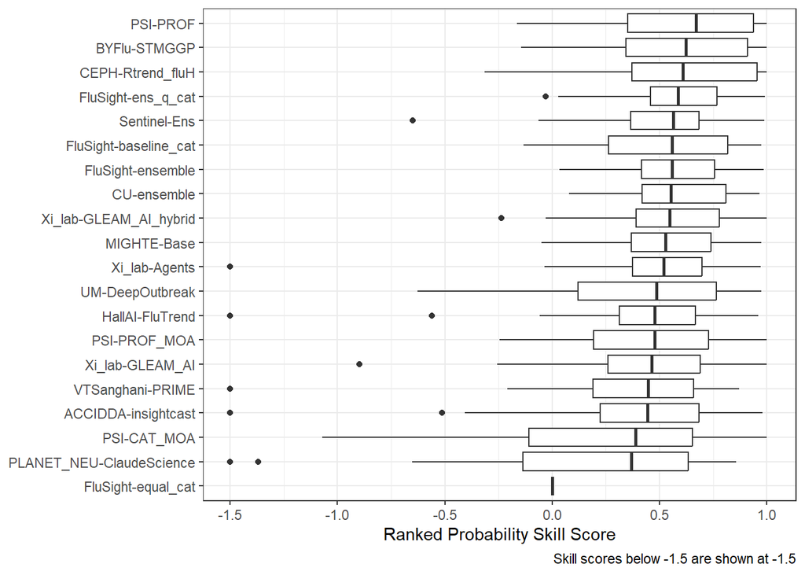

##### BSS

BSS for model across locations

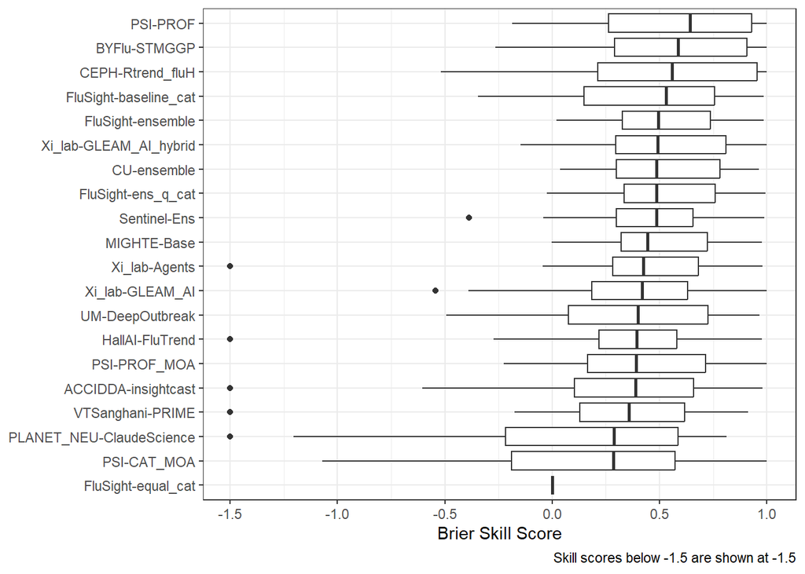

### Historical Accuracy

#### Tables

##### RPSS

[interactive table not shown]

##### BSS

[interactive table not shown]

#### Boxplots

##### RPSS

RPSS for model across locations

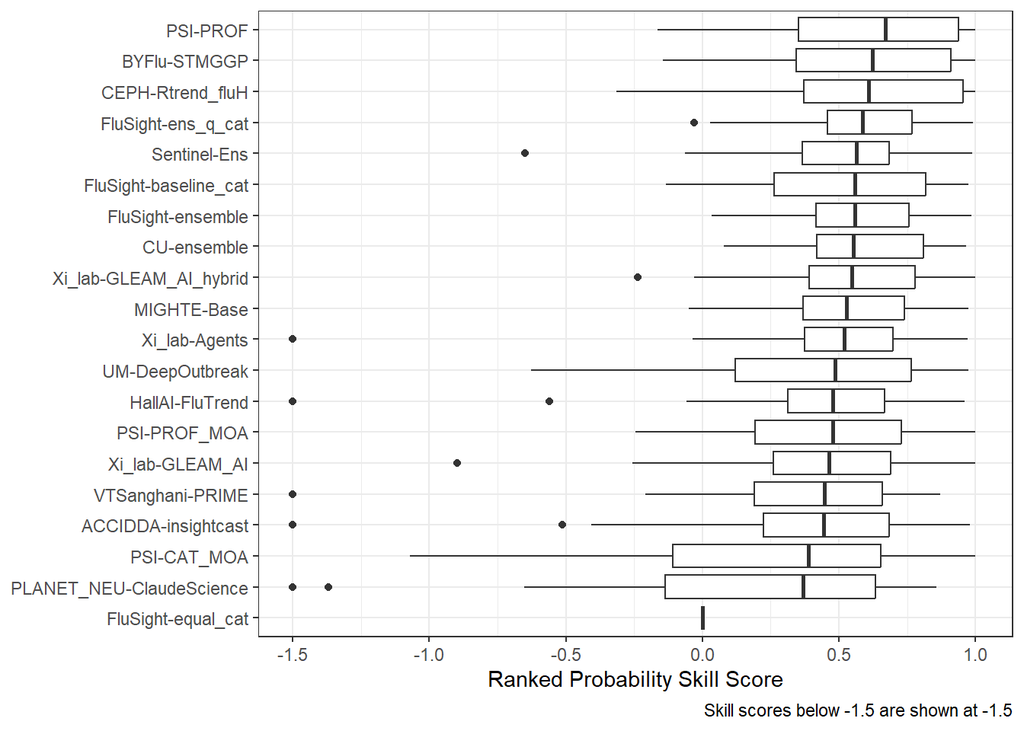

##### BSS

BSS for model across locations

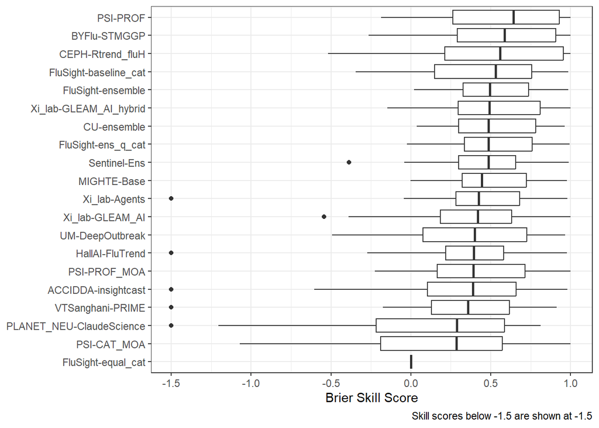

## Metrics by model

### Brier

#### Horizon 0

[interactive chart not shown]

#### Horizon 1

[interactive chart not shown]

### RPS

#### Horizon 0

[interactive chart not shown]

#### Horizon 1

[interactive chart not shown]

## Evaluation by location

Using all data. Any skill scores less than -10 were capped at -10.

### Ranked Probability Skill Score

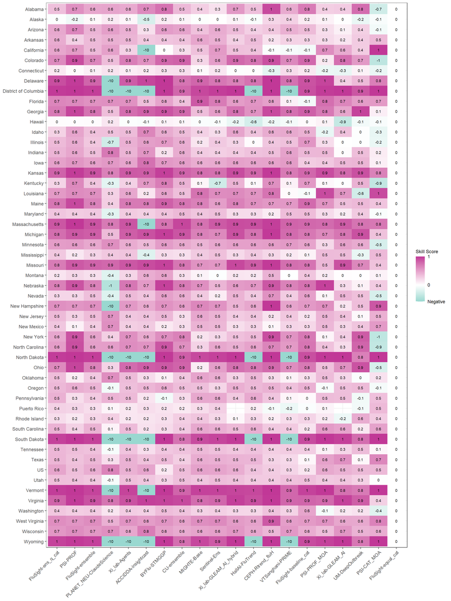

### Brier Skill Score

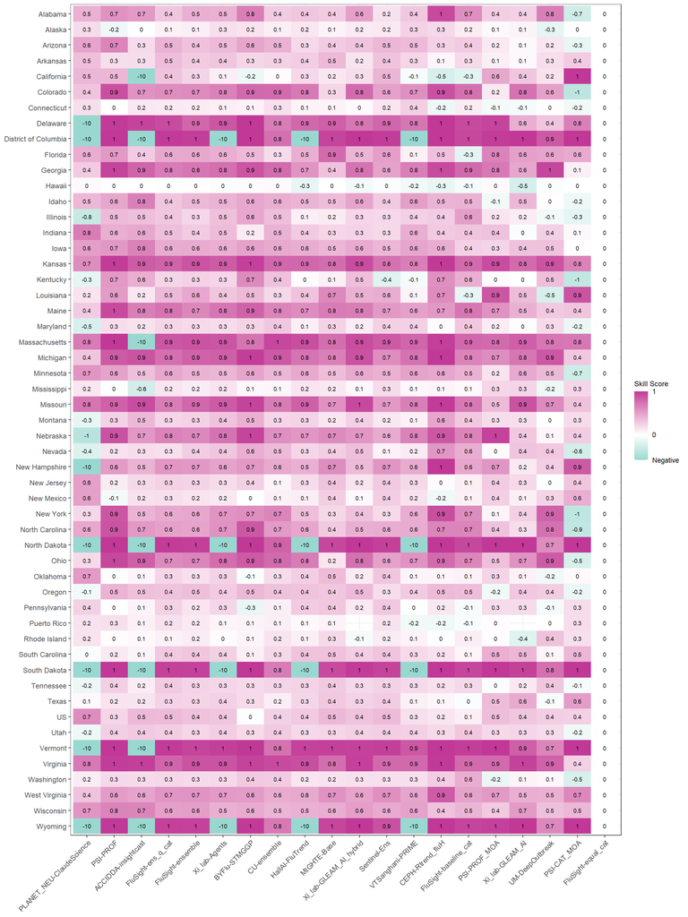

## Forecast trend for reference date October 24, 2026

### Probability of any increase

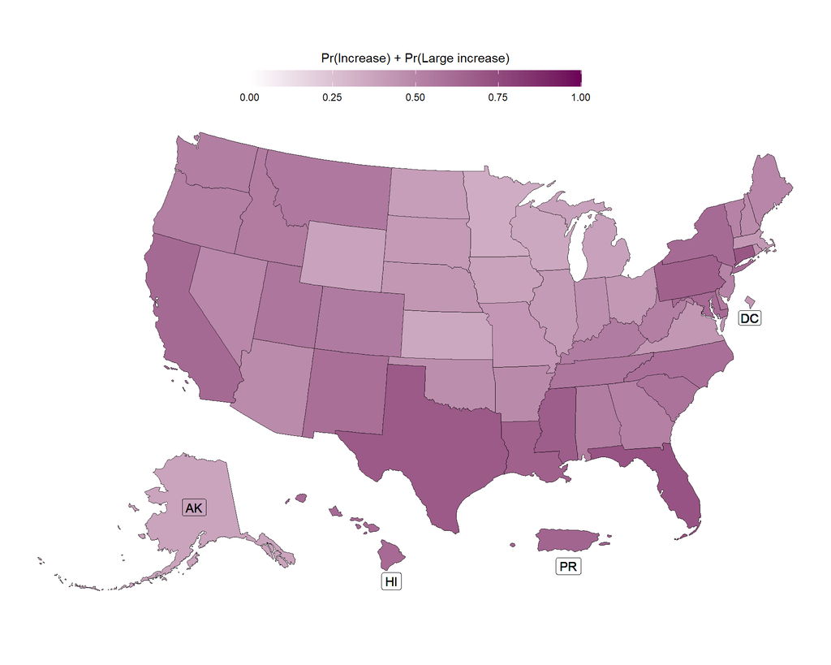

### Probability of any decrease

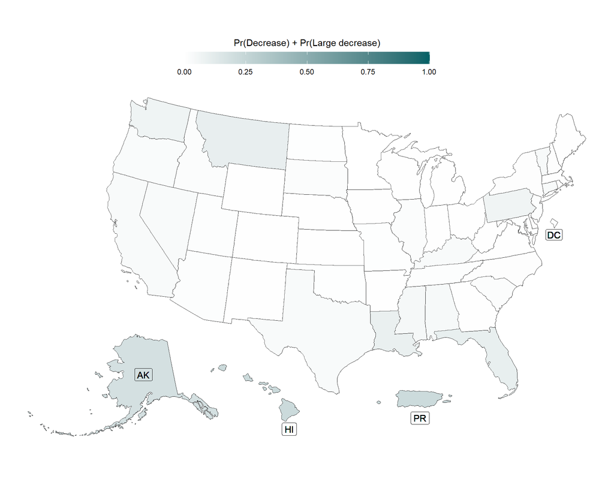

### Evaluation Periods

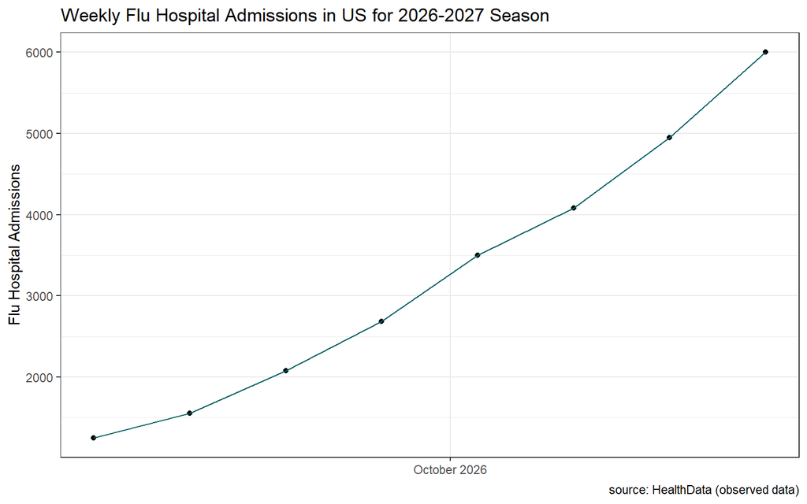